# Statistical inference with the GSS data

## Setup

### Load packages

```r
library(dplyr)
library(ggplot2)
library(olsrr)
library(tidyr)
library(gplots)
library(knitr)
```

### Load data

```r
load("gss.Rdata")
```

## Part 1: Data

The data comes from the General Social Surveys conducted by the National Opinion Research Center using a standard questionaire. Surveys were conducted in 1972, 1973, 1974, 1975, 1976, 1977, 1978, 1980, 1982, 1983, 1984, 1985, 1986, 1987, 1988, 1989, 1990, 1991, 1993, 1994, 1996, 1998, 2000, 2002, 2004, 2006, 2008, 2010, 2012, 2014, and 2016. A total of 62,466 interviews have been conducted, with the median length of the interview being about one and one-half hours.

Surveys from 1972 through 2004 were independently drawn samples of English-speaking persons 18 years of age or over, living in non-institutional arrangements within the United States. Starting in 2006 Spanish-speakers were added to the target population.

Until 2000, the survey was administered in a paper-and-pencil format, but starting in 2002, the GSS was conducted by computer-assisted personal interviewing (CAPI).

### Scope of Inference:

The data include a large number of randomly drawn responses, so it is generalizable to the target population of persons 18 years old or older living in non-institutional arrangements within the United States.

This study is observational without random assignment, and therefore no causal relationships can be inferred from this data. The length of the study might be a concern in that respondents may become fatigued with such a long questionaire and begin to give less accurate responses.

## Part 2: Research question

I’m interested in racial diversity issues particularly related to income inequality. I’m curious to see if household incomes for black families vary by region. Therefore, my research question is:

Does the constant annual family income (dollars adjusted for inflation) of respondents who self-idenfify as black differ significantly by region?

To answer this question I will be comparing means from multiple groups. The appropriate method for this situation is an ANOVA analysis to determine if there are any differences in means between groups. I will follow the ANOVA up with pair-wise t-tests with adusted p-values to control type 1 error. From the t-tests I hope to discover regions that seem either more or less favorable to the mean constant incomes of black households.

## Part 3: Exploratory data analysis

To get the dataset I need to answer my research question I will reduce the data to the constant incomes reported by self-identified black respondents in all nine regions. I’ll then remove any records with missing data and look at the counts by region to make sure I have enough data from each region.

```r
# creat my data

mydata<-gss %>%
  select(race, coninc, region) %>%
  filter(race != "Other" & race !="White") %>%
  select(region, coninc)

# get rid of N/As

completes<-complete.cases(mydata)
mydata<-mydata[completes,]

#  Check counts of respondents by region

mydatasum<-mydata %>%
  group_by(region) %>%
  summarise(n=n())

kable(mydatasum)
```

| region | n |
| --- | --- |
| New England | 112 |
| Middle Atlantic | 1068 |
| E. Nor. Central | 1180 |
| W. Nor. Central | 313 |
| South Atlantic | 2114 |
| E. Sou. Central | 714 |
| W. Sou. Central | 884 |
| Mountain | 78 |
| Pacific | 493 |

The smallest sample (78) comes from the Mountain region. It seems reasonable to assume that the number of samples in each region is less than 10% of the total population, which will be important in meeting the conditions for ANOVA.

I’ll now organize a table of summary statistics:

```r
sum1<- mydata %>%
  group_by(region) %>%
  summarise(Q1=quantile(coninc, .25), Mean=mean(coninc), Median=median(coninc),
            Q3=quantile(coninc, .75), IQR=IQR(coninc), StDev=sd(coninc)) %>%
  mutate(Skew=ifelse(Mean>Median, "Right", "Left"))

kable(sum1)
```

| region | Q1 | Mean | Median | Q3 | IQR | StDev | Skew |
| --- | --- | --- | --- | --- | --- | --- | --- |
| New England | 13957.5 | 39740.34 | 30395 | 57493.0 | 43535.5 | 34714.86 | Right |
| Middle Atlantic | 12077.0 | 33737.52 | 25926 | 47115.0 | 35038.0 | 28981.99 | Right |
| E. Nor. Central | 11243.0 | 33391.92 | 24882 | 47115.0 | 35872.0 | 30289.62 | Right |
| W. Nor. Central | 9932.0 | 27955.19 | 20673 | 37373.0 | 27441.0 | 25110.40 | Right |
| South Atlantic | 11111.0 | 30765.34 | 23847 | 42083.0 | 30972.0 | 27662.06 | Right |
| E. Sou. Central | 7294.5 | 22454.67 | 15377 | 28189.5 | 20895.0 | 23503.27 | Right |
| W. Sou. Central | 6717.0 | 23349.99 | 17280 | 33079.0 | 26362.0 | 22870.42 | Right |
| Mountain | 14544.5 | 36110.00 | 25015 | 45536.0 | 30991.5 | 32602.01 | Right |
| Pacific | 11111.0 | 34084.07 | 24882 | 47319.0 | 36208.0 | 31109.54 | Right |

The summary statistics show that the constant income data is right skewed for all regions. In addition, there is a fair amount of variability in the center and spread of the distributions. The box plot below helps illustrate these characteristics:

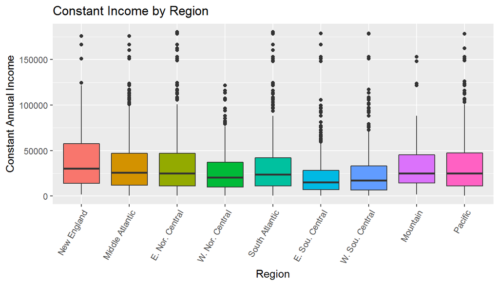

```r
p1<-ggplot(mydata, aes(x=factor(region), y=coninc, fill=factor(region)))+
  geom_boxplot()+ggtitle("Constant Income by Region")+
  theme(legend.position = "none", axis.text.x = element_text(angle = 60,hjust = 1))+
  xlab("Region")+ylab("Constant Annual Income")
p1
```

Near-normality for the constant income distributions by region is a concern as it is a condition for an ANOVA analysis. I will look at further examine this with the following qq plots:

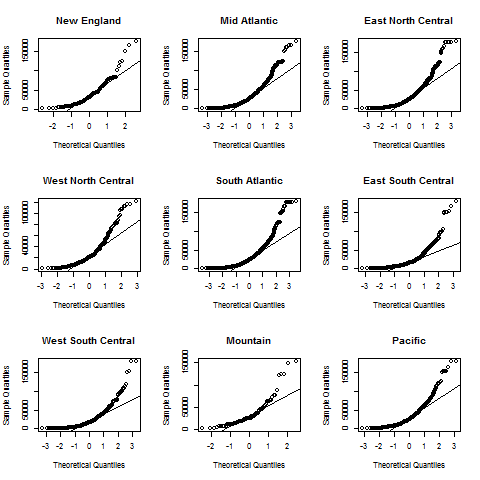

These plots indicate that the constant income varaible is not normal. To correct for this I’ll log transform the constant income data and then re-look at the summary statistics and normality using the log-transformed variable.

```r
# log transform

mydata$coninc<-log(mydata$coninc)

# EDA after log transform

sum2<- mydata %>%
  group_by(region) %>%
  summarise(Q1=quantile(coninc, .25), Mean=mean(coninc), Median=median(coninc),
            Q3=quantile(coninc, .75), IQR=IQR(coninc), StDev=sd(coninc)) %>%
  mutate(Skew=ifelse(Mean>Median, "Right", "Left"))

kable(sum2)
```

| region | Q1 | Mean | Median | Q3 | IQR | StDev | Skew |
| --- | --- | --- | --- | --- | --- | --- | --- |
| New England | 9.543273 | 10.179593 | 10.322033 | 10.95942 | 1.416146 | 0.9998411 | Left |
| Middle Atlantic | 9.399058 | 10.009125 | 10.163002 | 10.76035 | 1.361289 | 1.0409720 | Left |
| E. Nor. Central | 9.327501 | 9.969533 | 10.121900 | 10.76035 | 1.432846 | 1.0709546 | Left |
| W. Nor. Central | 9.203517 | 9.791182 | 9.936584 | 10.52870 | 1.325187 | 1.0700629 | Left |
| South Atlantic | 9.315691 | 9.900492 | 10.079414 | 10.64740 | 1.331708 | 1.0637429 | Left |
| E. Sou. Central | 8.894876 | 9.533858 | 9.640628 | 10.24670 | 1.351827 | 1.0869515 | Left |
| W. Sou. Central | 8.812397 | 9.554312 | 9.757286 | 10.40665 | 1.594257 | 1.1455412 | Left |
| Mountain | 9.584738 | 10.132406 | 10.127217 | 10.72624 | 1.141506 | 0.9012662 | Right |
| Pacific | 9.315691 | 9.972175 | 10.121900 | 10.76467 | 1.448976 | 1.1169541 | Left |

The log transformation has flipped the skew from right to left in all but on region, and has tightened up the center and spread as well - as we can see from the box plot below:

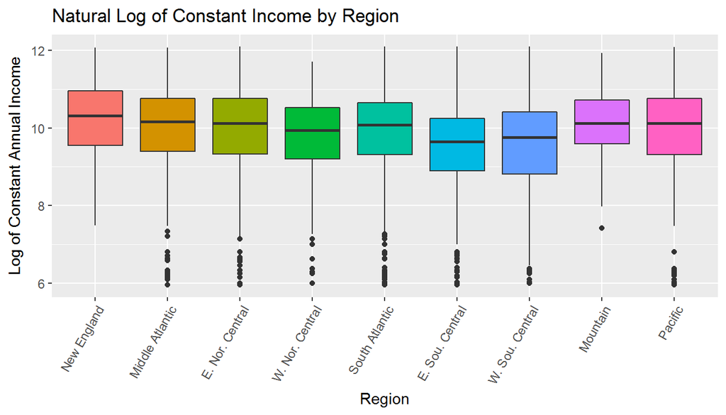

```r
p2<-ggplot(mydata, aes(x=factor(region), y=coninc, fill=factor(region)))+
  geom_boxplot()+ggtitle("Natural Log of Constant Income by Region")+
  theme(legend.position = "none", axis.text.x = element_text(angle = 60,hjust = 1))+
  xlab("Region")+ylab("Log of Constant Annual Income")

p2
```

In addition, the log transformed distribution is much more normal as evidenced by these plots:

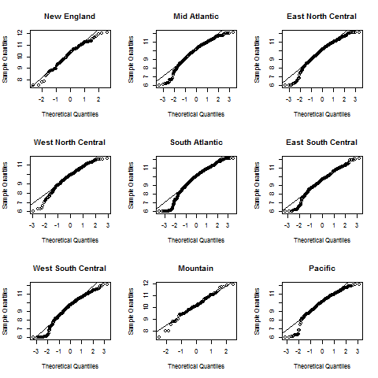

## Part 4: Inference

### ANOVA Conditions

I will first perform an ANOVA on the regions. The conditions for ANOVA are as follows:

#### Independence within groups

Since the survey is a random sample, and the number of samples in each group is less than 10% of the total population, this condition is met.

#### Independence between groups

Since respondents could not live within two different regions at the same time, this condition is also met.

#### Near normal distributions

The raw constant income data was not normal, but the log transformed data is nearly normal.

#### Similar variance between groups

Again, the raw data was problematic in terms of this condition. Once the data was log transformed, the variance between groups tightened up considerably. To be sure, I ran the following test for heteroscedasticity:

```r
# Test for heteroscedasticity

model<-lm(coninc~region, data=mydata)

ols_test_f(model, rhs = T)
```

```
##
##  F Test for Heteroskedasticity
##  -----------------------------
##  Ho: Variance is homogenous
##  Ha: Variance is not homogenous
##
##  Variables: regionMiddle Atlantic regionE. Nor. Central regionW. Nor. Central regionSouth Atlantic regionE. Sou. Central regionW. Sou. Central regionMountain regionPacific
##
##       Test Summary
##  ------------------------
##  Num DF     =    8
##  Den DF     =    6947
##  F          =    1.329803
##  Prob > F   =    0.223258
```

Since the p-value from the test is higher than the .05 threshold, we fail to reject the null hypothesis that the between group variance is homogenous.

Since we have met the conditions for ANOVA, I’ll now move on to the analysis itself.

### ANOVA analysis in r:

The hypotheses are:

H0 = the mean of constant income is the same for all regions

HA = at least one pair of regions have constant income means that are different from each other

```r
# ANOVA on log transformed data

aov<-aov(coninc~region, mydata)

summary(aov)
```

```
##               Df Sum Sq Mean Sq F value Pr(>F)
## region         8    225  28.079   24.25 <2e-16 ***
## Residuals   6947   8045   1.158
## ---
## Signif. codes:  0 '***' 0.001 '**' 0.01 '*' 0.05 '.' 0.1 ' ' 1
```

## Interpretation of ANOVA

The high F value and very low p value indicate that we should reject the null hypothesis that there is no difference in mean contstant income between the regions. With the ANOVA test, no confidence interval is generated, so inference is derived from the p-value. We can say that the data suggest that there is a significant difference in the mean constant income between at least two of the regions.

## Region by Region t-tests

I want to discover which regions have significant differences in mean constant income, so I will run a t-test on all possible combinations of regions, using the bonferroni correction to control for type 1 errors.

```r
ttable<-pairwise.t.test(mydata$coninc, mydata$region, p.adj="bonf")

kable(ttable$p.value)
```

|  | New England | Middle Atlantic | E. Nor. Central | W. Nor. Central | South Atlantic | E. Sou. Central | W. Sou. Central | Mountain |
| --- | --- | --- | --- | --- | --- | --- | --- | --- |
| Middle Atlantic | 1.0000000 | NA | NA | NA | NA | NA | NA | NA |
| E. Nor. Central | 1.0000000 | 1.0000000 | NA | NA | NA | NA | NA | NA |
| W. Nor. Central | 0.0378192 | 0.0588409 | 0.3298026 | NA | NA | NA | NA | NA |
| South Atlantic | 0.2698091 | 0.2586484 | 1.0000000 | 1.0000000 | NA | NA | NA | NA |
| E. Sou. Central | 0.0000001 | 0.0000000 | 0.0000000 | 0.0152084 | 0 | NA | NA | NA |
| W. Sou. Central | 0.0000003 | 0.0000000 | 0.0000000 | 0.0296164 | 0 | 1.0000000 | NA | NA |
| Mountain | 1.0000000 | 1.0000000 | 1.0000000 | 0.4409549 | 1 | 0.0001137 | 0.0001983 | NA |
| Pacific | 1.0000000 | 1.0000000 | 1.0000000 | 0.7194980 | 1 | 0.0000000 | 0.0000000 | 1 |

### Interpretation of Results of Region by Region t-tests

The pairwise.t.test with the p.adj function returns an adjusted p-value. The p-values are adjusted upwards based on the correction method selected, in this case, the bonferroni correction. This means that we’ll interpret the p-values normally, looking for those less than .o5 to reject the null hypothesis of no difference in means.

A close inspection of the table shows that we reject the null in all cases for both the the East South Central and West South Central regions. The states included in these regions are Alabama, Arkansas, Kentucky, Louisiana, Mississippi, Oklahoma, Tennessee and Texas. Looking at the summary tables we see that the mean constant incomes in these states are lower than the other regions. Therefore, the data suggest that it is highly unlikely that these lower mean constant incomes are due to random chance, and that further investigation into this would be worthwhile.

A map and further information on the regions can be found here:

https://www2.census.gov/geo/pdfs/maps-data/maps/reference/us_regdiv.pdf

All of the r code for this analysis can be found here:

https://github.com/lecroc/Inferential-Statistics